# Reproducible Research - Assignment 1

Ronald Armando

5/8/2018

```r
rm(list=ls())
```

```r
library(ggplot2)
library(scales)
library(dplyr)
library(Hmisc)
```

## Introduction

It is now possible to collect a large amount of data about personal movement using activity monitoring devices such as a Fitbit, Nike Fuelband, or Jawbone Up. These type of devices are part of the “quantified self” movement – a group of enthusiasts who take measurements about themselves regularly to improve their health, to find patterns in their behavior, or because they are tech geeks. But these data remain under-utilized both because the raw data are hard to obtain and there is a lack of statistical methods and software for processing and interpreting the data.

This assignment makes use of data from a personal activity monitoring device. This device collects data at 5 minute intervals through out the day. The data consists of two months of data from an anonymous individual collected during the months of October and November, 2012 and include the number of steps taken in 5 minute intervals each day.

## Loading and preprocessing the data

```r
data <- read.csv('activity.csv')
```

```r
str(data)
```

```
## 'data.frame':    17568 obs. of  3 variables:
##  $ steps   : int  NA NA NA NA NA NA NA NA NA NA ...
##  $ date    : Factor w/ 61 levels "2012-10-01","2012-10-02",..: 1 1 1 1 1 1 1 1 1 1 ...
##  $ interval: int  0 5 10 15 20 25 30 35 40 45 ...
```

By using the str() function, we see that the dataset has 3 variables: steps, date and interval. We also see that there are many NA values in the steps variable.

For the moment, we won’t change the formart of the dataset.

## Mean total number of steps taken per day

For this part of the assignment, we will ignore the missing values in the dataset.

##### 1. What is mean total number of steps taken per day?

```r
stepsDay <- aggregate(data$steps, list(data$date), sum, na.rm=TRUE)
names(stepsDay)<-c("date", "steps")
```

##### 2. Make a histogram of the total number of steps taken each day

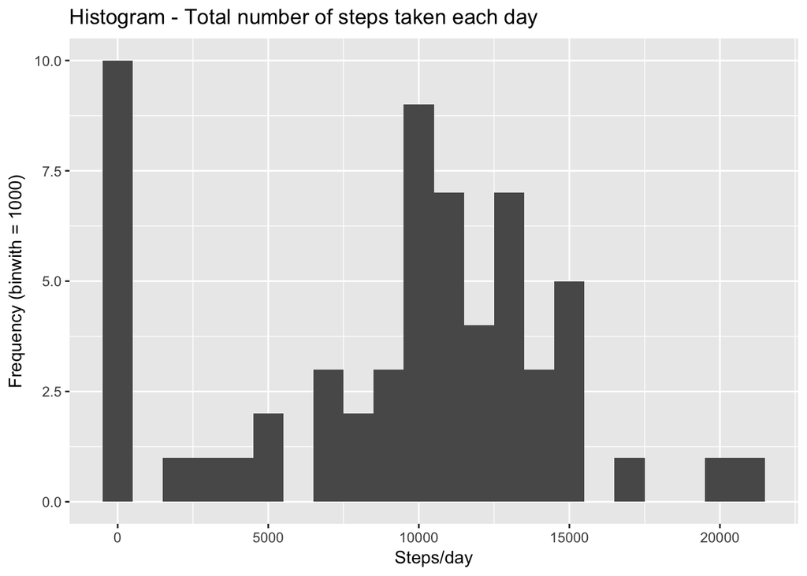

```r
qplot(stepsDay$steps,
      xlab='Steps/day',
      ylab='Frequency (binwith = 1000)',
      main = 'Histogram - Total number of steps taken each day',
      binwidth=1000)
```

##### 3. Calculate and report the mean and median total number of steps taken per day

```r
stepsDMean <- mean(stepsDay$steps)
stepsDMedian <- median(stepsDay$steps)
```

- Mean: 9354.2295082
- Median: 10395